# Fully Deployed Front to Back End Fantasy Projection Model in R

68.80%

1.00%

1.00%

PG

[figure not shown]

Trey Burke

66.70%

83.30%

83.30%

PG

[figure not shown]

Tre Jones

66.70%

66.70%

66.70%

PG

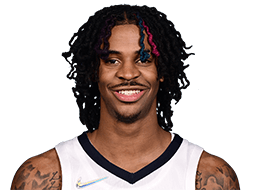

Ja Morant

58.60%

60.30%

61.90%

SF

SF

[figure not shown]

Thanasis Antetokounmpo

80.00%

80.00%

83.30%

SF

[figure not shown]

Kenyon Martin Jr.

75.00%

75.00%

71.70%

SF

[figure not shown]

Deni Avdija

66.70%

75.00%

72.70%

SF

[figure not shown]

Dalano Banton

66.70%

75.00%

75.00%

SF

[figure not shown]

Andre Iguodala

66.70%

77.80%

81.00%

SG

SG

[figure not shown]

Anfernee Simons

83.30%

91.70%

91.70%

SG

[figure not shown]

Seth Curry

76.50%

94.10%

92.30%

SG

[figure not shown]

John Konchar

66.70%

66.70%

66.70%

SG

[figure not shown]

Eric Bledsoe

62.50%

65.60%

63.50%

SG

[figure not shown]

Zach LaVine

61.10%

70.80%

76.70%

```r
# top5_fg %>%
#   gtsave(here::here("images/top5.png"))
```

## Analysis

Finally, some machine learning, first we filter down to the relevant variables and start off by using the relevant variables for our model to predict maximum fantasy points.

```r
normal_df <- df %>%
  mutate(id = slugPlayerSeason) %>%
  transmute(count_games = countGames,
            count_games_started = countGamesStarted,
            pct_fg = pctFG,
            pct_fg3 = pctFG3,
            pct_fg2 = pctFG2,
            pct_efg = pctEFG,
            pct_ft = pctFT,
            minutes = minutesTotals,
            fgm_total = fgmTotals,
            fga_total = fgaTotals,
            fg3m_totals = fg3mTotals,
            fg3a_totals = fg3aTotals,
            fg2m_totals = fg2mTotals,
            fg2a_totals = fg2aTotals,
            ftm_totals = ftmTotals,
            fta_totals = ftaTotals,
            orb_totals = orbTotals,
            drb_totals = drbTotals,
            trb_totals = trbTotals,
            ast_totals = astTotals,
            stl_totals = stlTotals,
            blk_totals = blkTotals,
            tov_totals = tovTotals,
            pf_totals = pfTotals,
            pts_totals = ptsTotals,
            fantasy_points = fantasy_points)
```

## Data Exploration

Lots of statistics here idk really.

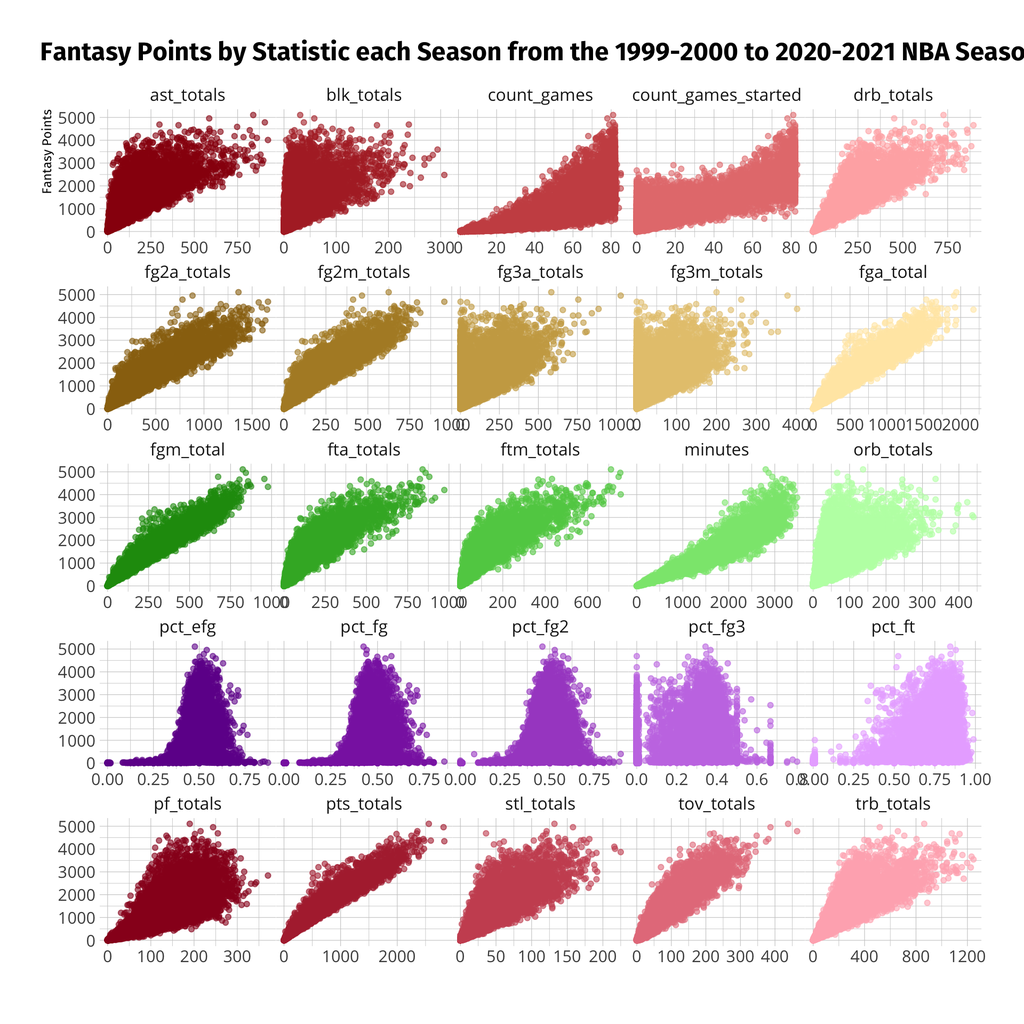

```r
normal_df %>%
  pivot_longer(count_games:pts_totals, names_to = "stat", values_to = "value") %>%
  ggplot(aes(value, fantasy_points, color = stat)) +
  geom_point(alpha = 0.6) +
  ggtitle("Fantasy Points by Statistic each Season from the 1999-2000 to 2020-2021 NBA Season") +
  labs(y = "Fantasy Points", x = "") +
  paletteer::scale_color_paletteer_d(palette = "dichromat::SteppedSequential_5") +
  facet_wrap( ~ stat, ncol = 5, scales = "free_x") +
  theme(legend.position = "none")
```

```r
ggsave(here::here("images/eda_points_stat.png"), width = 10, height = 10)
```

## Building a Model

We start by loading the tidymodels metapackage, and splitting the data into training and testing sets.

```r
# Later add a part to strata by 3 point era?
library(tidymodels)

set.seed(2021)
nba_split <- initial_split(normal_df)
nba_train <- training(nba_split)
nba_test <- testing(nba_split)
```

An XGBoost model is based on trees, so we don’t have to do anymore preprocessing than has already been done on the data, we can go straight into model specification and hyperparameter tuning.

```r
xgb_spec <- boost_tree(
  trees = 1000,
  tree_depth = tune(), min_n = tune(),
  loss_reduction = tune(),                     ## first three: model complexity
  sample_size = tune(), mtry = tune(),         ## randomness
  learn_rate = tune()                          ## step size
) %>%
  set_engine("xgboost") %>%
  set_mode("regression")

xgb_spec
```

```
## Boosted Tree Model Specification (regression)
##
## Main Arguments:
##   mtry = tune()
##   trees = 1000
##   min_n = tune()
##   tree_depth = tune()
##   learn_rate = tune()
##   loss_reduction = tune()
##   sample_size = tune()
##
## Computational engine: xgboost
```

Thats a lot right there so lets create a space-filling design to cover the hyperparameter space as efficiently as possible.

```r
xgb_grid <- grid_latin_hypercube(
  tree_depth(),
  min_n(),
  loss_reduction(),
  sample_size = sample_prop(),
  finalize(mtry(), nba_train),
  learn_rate(),
  size = 30
)

xgb_grid
```

```
## # A tibble: 30 × 6
##    tree_depth min_n loss_reduction sample_size  mtry learn_rate
##         <int> <int>          <dbl>       <dbl> <int>      <dbl>
##  1         15    18       3.42e- 8       0.548     9   1.03e- 4
##  2          3     4       6.00e- 4       0.958     7   8.72e- 8
##  3          2    31       1.87e- 8       0.344     6   4.87e-10
##  4         11    27       2.00e- 6       0.857     4   8.89e- 4
##  5          2    33       3.96e- 3       0.924     2   2.24e- 6
##  6          6    15       3.71e- 5       0.804     8   2.13e- 7
##  7          9     5       4.59e- 7       0.377    24   1.39e- 8
##  8         12     6       3.54e- 2       0.270    14   7.59e- 2
##  9         12    12       8.89e-10       0.763    18   1.92e-10
## 10          4     9       1.79e- 1       0.121    18   3.51e- 3
## # … with 20 more rows
```

Note that `mtry()` had to be treated differently because it depends on the number of predictors in the data.

The model specification in the workflow must be put in for convenience. since theres no preprocessing necessary here we can go straight to `add_formula()` as our data preprocessor.

```r
xgb_wf <- workflow() %>%
  add_formula(fantasy_points ~ .) %>%
  add_model(xgb_spec)

xgb_wf
```

```
## ══ Workflow ════════════════════════════════════════════════════════════════════
## Preprocessor: Formula
## Model: boost_tree()
##
## ── Preprocessor ────────────────────────────────────────────────────────────────
## fantasy_points ~ .
##
## ── Model ───────────────────────────────────────────────────────────────────────
## Boosted Tree Model Specification (regression)
##
## Main Arguments:
##   mtry = tune()
##   trees = 1000
##   min_n = tune()
##   tree_depth = tune()
##   learn_rate = tune()
##   loss_reduction = tune()
##   sample_size = tune()
##
## Computational engine: xgboost
```

Next we create the cross-validation resamples for tuning the model.

```r
set.seed(2021)
nba_folds <- vfold_cv(nba_train)

nba_folds
```

```
## #  10-fold cross-validation
## # A tibble: 10 × 2
##    splits             id
##    <list>             <chr>
##  1 <split [7007/779]> Fold01
##  2 <split [7007/779]> Fold02
##  3 <split [7007/779]> Fold03
##  4 <split [7007/779]> Fold04
##  5 <split [7007/779]> Fold05
##  6 <split [7007/779]> Fold06
##  7 <split [7008/778]> Fold07
##  8 <split [7008/778]> Fold08
##  9 <split [7008/778]> Fold09
## 10 <split [7008/778]> Fold10
```

Now we get ready for the big task, tuning the grid with `tune_grid()` using the workflow, resamples, and grid of paramaters to try. We use `control_grid(save_pred = T)` to explore predictions afterwards.

```r
doParallel::registerDoParallel()

set.seed(2021)
xgb_res <- tune_grid(
  xgb_wf,
  resamples = nba_folds,
  grid = xgb_grid,
  control = control_grid(save_pred = T)
)
```

```r
xgb_res
```

```
## # Tuning results
## # 10-fold cross-validation
## # A tibble: 10 × 5
##    splits             id     .metrics           .notes           .predictions
##    <list>             <chr>  <list>             <list>           <list>
##  1 <split [7007/779]> Fold01 <tibble [60 × 10]> <tibble [0 × 1]> <tibble [23,37…
##  2 <split [7007/779]> Fold02 <tibble [60 × 10]> <tibble [0 × 1]> <tibble [23,37…
##  3 <split [7007/779]> Fold03 <tibble [60 × 10]> <tibble [0 × 1]> <tibble [23,37…
##  4 <split [7007/779]> Fold04 <tibble [60 × 10]> <tibble [0 × 1]> <tibble [23,37…
##  5 <split [7007/779]> Fold05 <tibble [60 × 10]> <tibble [0 × 1]> <tibble [23,37…
##  6 <split [7007/779]> Fold06 <tibble [60 × 10]> <tibble [0 × 1]> <tibble [23,37…
##  7 <split [7008/778]> Fold07 <tibble [60 × 10]> <tibble [0 × 1]> <tibble [23,34…
##  8 <split [7008/778]> Fold08 <tibble [60 × 10]> <tibble [0 × 1]> <tibble [23,34…
##  9 <split [7008/778]> Fold09 <tibble [60 × 10]> <tibble [0 × 1]> <tibble [23,34…
## 10 <split [7008/778]> Fold10 <tibble [60 × 10]> <tibble [0 × 1]> <tibble [23,34…
```

## Exploring Results

It’s easy to explore all metrics for the models with `collect_metrics()`!

```r
collect_metrics(xgb_res)
```

```
## # A tibble: 60 × 12
##     mtry min_n tree_depth learn_rate loss_reduction sample_size .metric
##    <int> <int>      <int>      <dbl>          <dbl>       <dbl> <chr>
##  1     9    18         15   1.03e- 4   0.0000000342       0.548 rmse
##  2     9    18         15   1.03e- 4   0.0000000342       0.548 rsq
##  3     7     4          3   8.72e- 8   0.000600           0.958 rmse
##  4     7     4          3   8.72e- 8   0.000600           0.958 rsq
##  5     6    31          2   4.87e-10   0.0000000187       0.344 rmse
##  6     6    31          2   4.87e-10   0.0000000187       0.344 rsq
##  7     4    27         11   8.89e- 4   0.00000200         0.857 rmse
##  8     4    27         11   8.89e- 4   0.00000200         0.857 rsq
##  9     2    33          2   2.24e- 6   0.00396            0.924 rmse
## 10     2    33          2   2.24e- 6   0.00396            0.924 rsq
## # … with 50 more rows, and 5 more variables: .estimator <chr>, mean <dbl>,
## #   n <int>, std_err <dbl>, .config <chr>
```

We can visualize these easily as well to understand the results

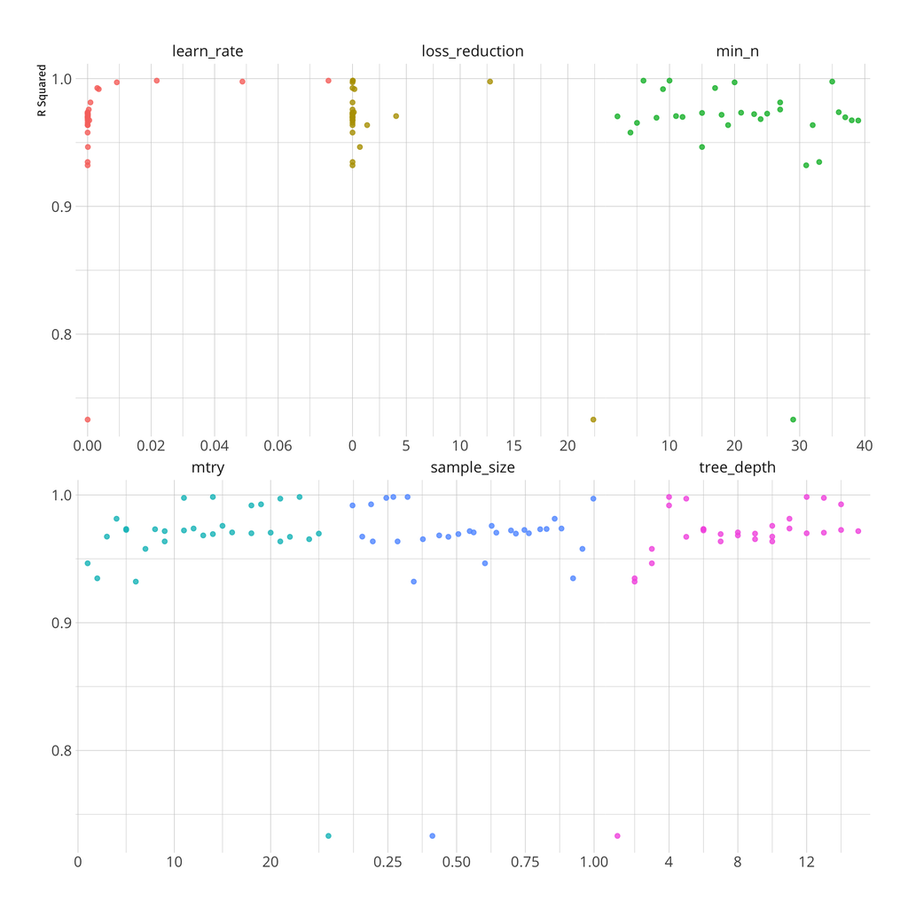

```r
xgb_res %>%
  collect_metrics() %>%
  filter(.metric == "rsq") %>%
  select(mean, mtry:sample_size) %>%
  pivot_longer(mtry:sample_size,
               values_to = "value",
               names_to = "parameter"
  ) %>%
  ggplot(aes(value, mean, color = parameter)) +
  geom_point(alpha = 0.8, show.legend = FALSE) +
  facet_wrap(~parameter, scales = "free_x") +
  labs(x = NULL, y = "R Squared")
```

And let tidymodels select the best performing set of paramaters for us with `show_best()`, its pretty convenient that the best rmse is also the best r-squared one.

```r
show_best(xgb_res, "rmse");show_best(xgb_res, "rsq")
```

```
## # A tibble: 5 × 12
##    mtry min_n tree_depth learn_rate loss_reduction sample_size .metric
##   <int> <int>      <int>      <dbl>          <dbl>       <dbl> <chr>
## 1    23    10          4    0.0218     0.0142            0.322 rmse
## 2    14     6         12    0.0759     0.0354            0.270 rmse
## 3    11    35         13    0.0488    12.8               0.244 rmse
## 4    21    20          5    0.00920    0.000000213       0.997 rmse
## 5    18     9          4    0.00351    0.179             0.121 rmse
## # … with 5 more variables: .estimator <chr>, mean <dbl>, n <int>,
## #   std_err <dbl>, .config <chr>
```

```
## # A tibble: 5 × 12
##    mtry min_n tree_depth learn_rate loss_reduction sample_size .metric
##   <int> <int>      <int>      <dbl>          <dbl>       <dbl> <chr>
## 1    23    10          4    0.0218        1.42e- 2       0.322 rsq
## 2    14     6         12    0.0759        3.54e- 2       0.270 rsq
## 3    11    35         13    0.0488        1.28e+ 1       0.244 rsq
## 4    21    20          5    0.00920       2.13e- 7       0.997 rsq
## 5    19    17         14    0.00303       1.97e-10       0.189 rsq
## # … with 5 more variables: .estimator <chr>, mean <dbl>, n <int>,
## #   std_err <dbl>, .config <chr>
```

Or the best performing model overall

```r
best_rsq <- select_best(xgb_res, "rsq")
best_rsq
```

```
## # A tibble: 1 × 7
##    mtry min_n tree_depth learn_rate loss_reduction sample_size .config
##   <int> <int>      <int>      <dbl>          <dbl>       <dbl> <chr>
## 1    23    10          4     0.0218         0.0142       0.322 Preprocessor1_Mo…
```

Now to finalize the tuneable workflow with the paramater values we have

```r
final_xgb <- finalize_workflow(
  xgb_wf,
  best_rsq
)

final_xgb
```

```
## ══ Workflow ════════════════════════════════════════════════════════════════════
## Preprocessor: Formula
## Model: boost_tree()
##
## ── Preprocessor ────────────────────────────────────────────────────────────────
## fantasy_points ~ .
##
## ── Model ───────────────────────────────────────────────────────────────────────
## Boosted Tree Model Specification (regression)
##
## Main Arguments:
##   mtry = 23
##   trees = 1000
##   min_n = 10
##   tree_depth = 4
##   learn_rate = 0.0217749924129286
##   loss_reduction = 0.0141520961395455
##   sample_size = 0.321661404399201
##
## Computational engine: xgboost
```

Instead of `tune()` placeholders, we can use real values for the models hyperparameters.

Which of the parameters is most important for variable importance?

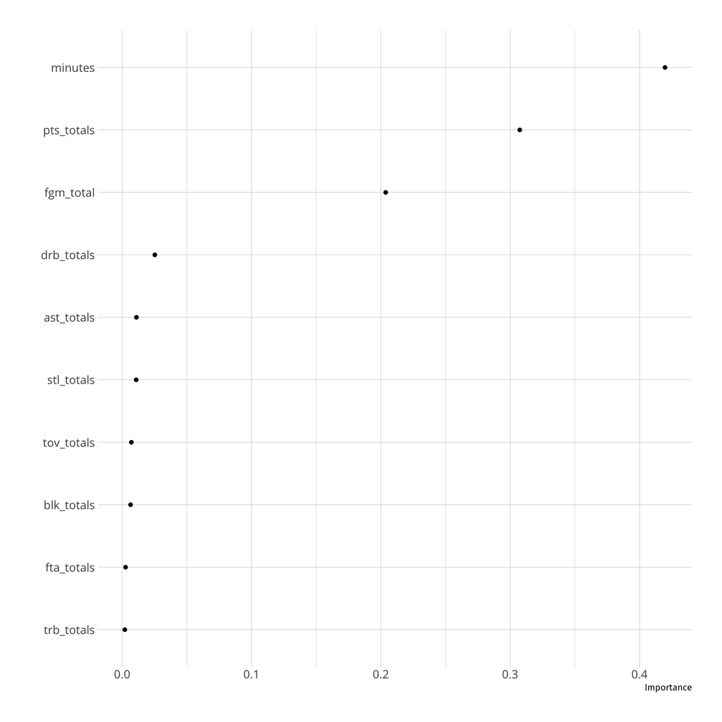

```r
library(vip)

final_xgb %>%
  fit(data = nba_train) %>%
  pull_workflow_fit() %>%
  vip(geom = "point")
```

Looks like minutes has the most importance, and then points, and then field goal makes.

And to save it with `xgboost::xgb.save()`! It can be reloaded later with `xgboost::xgb.load()`.

```r
final_xgb %>%
  fit(data = nba_train) %>%
  extract_fit_engine() %>%
  xgboost::xgb.save(., here::here("models/normal_model"))
```

```
## [1] TRUE
```

Finally lets use `last_fit()` to fit the model one last time on the training data and *evaluate* our model one last time on the testing set. Notice that this is the first time we have used the testing data during this whole modeling analysis.

```r
final_res <- last_fit(final_xgb, nba_split)

collect_metrics(final_res)
```

```
## # A tibble: 2 × 4
##   .metric .estimator .estimate .config
##   <chr>   <chr>          <dbl> <chr>
## 1 rmse    standard      34.5   Preprocessor1_Model1
## 2 rsq     standard       0.999 Preprocessor1_Model1
```

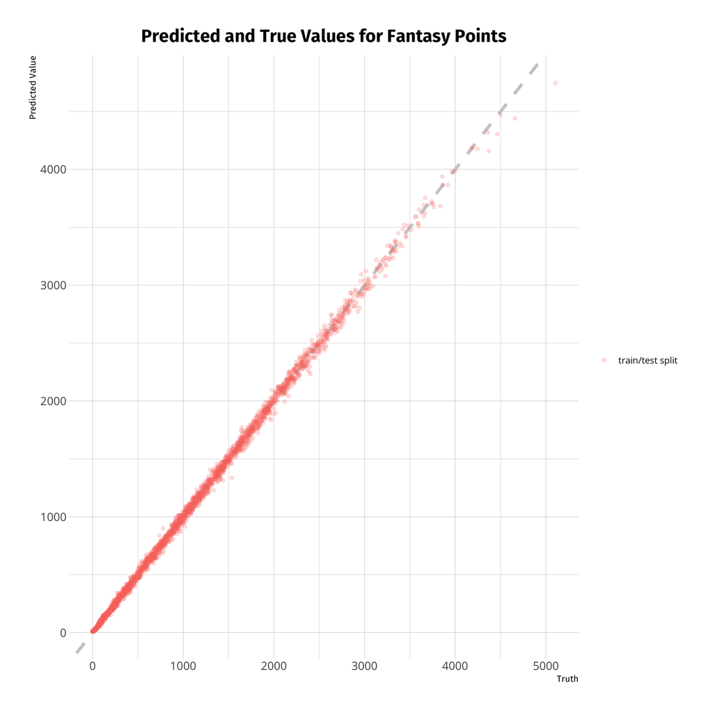

```r
final_res %>%
  collect_predictions() %>%
  ggplot(aes(fantasy_points, .pred, color = id)) +
  geom_abline(lty = 2, color = "gray80", size = 1.5) +
  geom_point(alpha = 0.2) +
  labs(x = "Truth", y = "Predicted Value",
       color = NULL,
       title = "Predicted and True Values for Fantasy Points")
```

[Shiny Apps](http://shinyapps.duncangates.me/) • [Github](http://www.github.com/dungates/)  
Copyright © Duncan Gates, 2021